# Analysing migration between Germany and other EU countries

Reza Hosseini

28 July 2016

## Synopsis

The aim of this study is to analyse the data of migration between Germany and other EU countries in the time frame between 1974 to 2014. We will explore the data analyse change in time, and relative to countries, use the data to forecast mogration in years 2015 and 2016.

## Data exploration

To have an understanding of the pattern here you can see the total number of arrivals and departures based on gender.

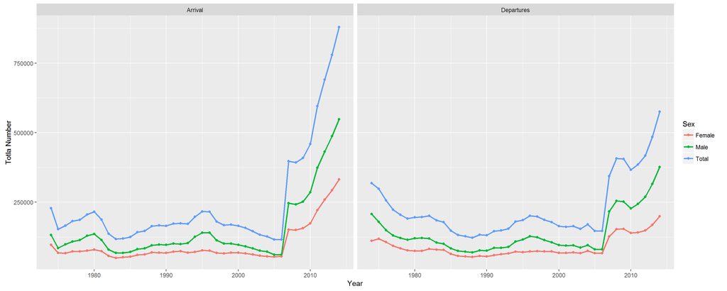

It can be seen that the trend in both arrivals and departures is roughly increasing specially from mid 2000’s. Also till mid 2000’s the number of departures is roughly equal and sometimes more that the number of arrivals. But from then the number of arrivals started increasing faster and gets higher than departures.

## The maximum number of departures/Arrivals

We want to explore how many people came and left when and where the most. These can be seen the best in the plots below

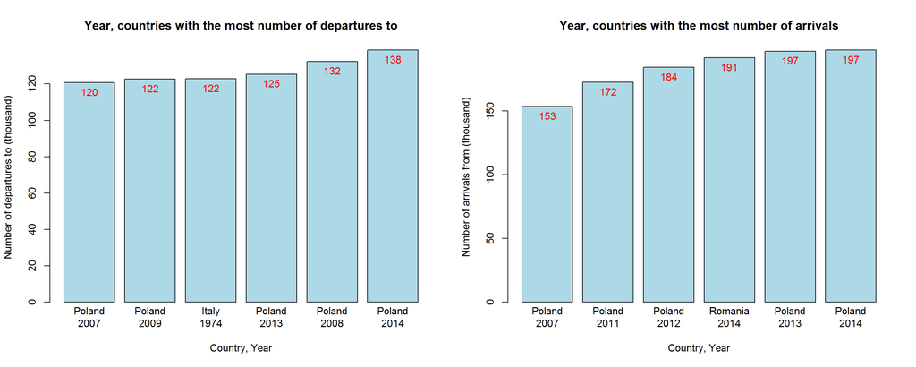

Based on the plots, in the yeras 2008 and 2014 respectively 132 and 138 thousand people have left Germany to Poland which are the most number of departures to a single country. Also in each of years 2013 and 2014, 197 thousand people came to Germany from again Poland.

## Forecasting

As no seasonal pattern could be seen in the data , I decided to use the random walk method for forecasting. The results of forecasting including 95 percent confidence intervals can be seen in the following charts.

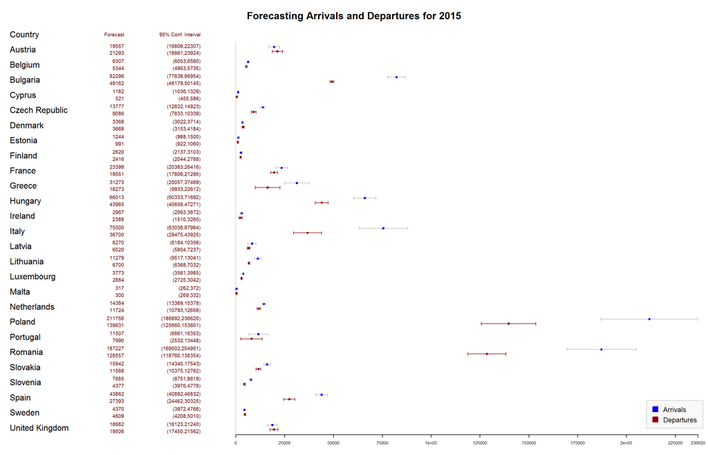

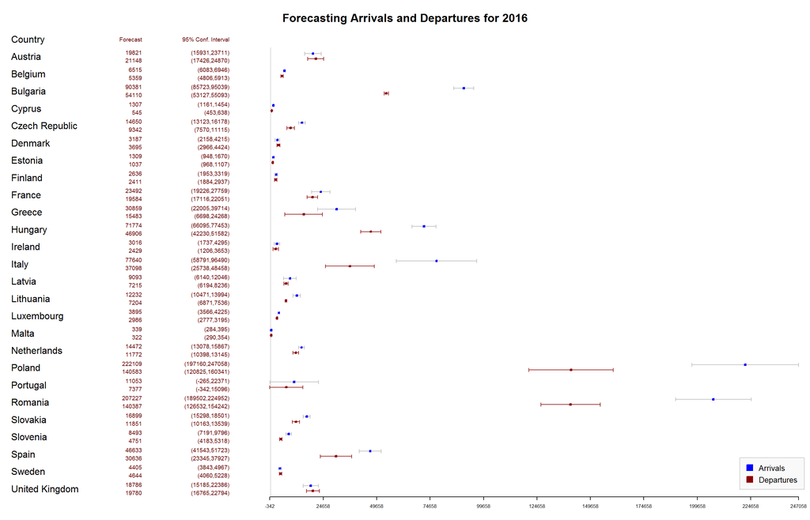

## Difference between the number of male and female immigrants

Looking at the charts of immigrants in years 2013 and 2014 it seems that there are more male immigrants than female.

##### **Imigrants departed from Germany in 2013**

[interactive chart not shown]

[interactive chart not shown]

## Reference

Statistisches Bundesamt, Wiesbaden 2016